# BRCA1 Expression Activation

BRCA1 is a tumor supressant gene related to various forms of breast cancer. A small molecule drug that increases BRCA1 activation could reduce tumor growth or make tumors more responsive to treatment.

This notebook reviews a BRCA1-expression bioassay and attempts to find small molecules that could be viable drug targets.

Bioassay data was obtained from PubChem: [QHTS Assay To Identify Small Molecule Activators Of BRCA1 Expression](https://pubchem.ncbi.nlm.nih.gov/bioassay/624202)

*Notebook created by Harrison Green*

```python
import pandas as pd
import numpy as np
import seaborn as sns
import matplotlib.pyplot as plt
%matplotlib inline
```

```python
from IPython.display import Image, HTML, display, SVG
```

```python
from rdkit import Chem
from rdkit.Chem import rdFMCS, rdDepictor, Draw, AllChem
from rdkit.Chem.Draw import rdMolDraw2D
from rdkit.Chem.Draw import IPythonConsole
```

```python
import pubchempy as pcp
```

```python
from bs4 import BeautifulSoup
import requests
import lxml
```

```python
import time
```

```python
from tqdm import tqdm
```

## BioAssay Data

Read the bioassay data into a Pandas data frame so we can work with it. The first 5 rows (not including the header) are column descriptors so we can skip them.

```python
brca1_raw = pd.read_csv('data/AID_624202_datatable_active.csv', skiprows=[1,2,3,4,5])

# fetch some useful columns and clean up
brca1_all = brca1_raw[['PUBCHEM_CID', 'PUBCHEM_ACTIVITY_SCORE', 'Potency', 'Efficacy']]
brca1_all.columns = ['cid','score','potency','efficacy']
brca1_all.head()
```

|  | cid | score | potency | efficacy |
| --- | --- | --- | --- | --- |
| 0 | 644438 | 50 | 3.9811 | 223.335 |
| 1 | 644503 | 43 | 10.0000 | 100.714 |
| 2 | 645056 | 43 | 11.2202 | 143.083 |
| 3 | 645119 | 42 | 11.2202 | 103.173 |
| 4 | 645165 | 45 | 10.0000 | 185.571 |

Let's plot the score distribution to see what we're dealing with.

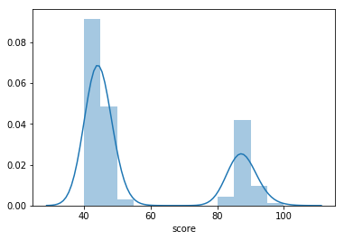

```python
sns.distplot(brca1_all['score'])
```

This BioAssay gives a molecule the "active" status if the score is between 40 and 100. However, there is a clear spike around the score minimum which indicates that some of the molecules assigned an "active" phenotype are really not doing much at all. We can just filter these out and plot again.

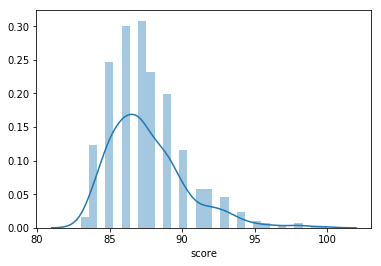

```python
brca1_active = brca1_all[brca1_all['score'] > 60]
sns.distplot(brca1_active['score'])
```

This histogram looks more like what we would expect with a range of varying active molecules.

## Top Molecules

Let's look at the top 10 molecules and their scores:

```python
brca1_active = brca1_active.sort_values(['score'],ascending=False)
brca1_active.head(10)
```

|  | cid | score | potency | efficacy |
| --- | --- | --- | --- | --- |
| 2643 | 844224 | 100 | 0.8913 | 296.791 |
| 1645 | 15991406 | 100 | 0.8913 | 256.432 |
| 3782 | 990823 | 99 | 1.7783 | 310.519 |
| 2772 | 977500 | 99 | 1.1220 | 235.957 |
| 1639 | 15987509 | 98 | 0.8913 | 242.718 |
| 2107 | 2150868 | 98 | 0.7943 | 160.406 |
| 3301 | 5054584 | 98 | 1.2589 | 268.722 |
| 1646 | 15991408 | 98 | 2.2387 | 262.622 |
| 2258 | 2317127 | 98 | 3.1623 | 359.905 |
| 2005 | 9567025 | 97 | 1.1220 | 255.743 |

## More data from PubChem

The cid doesn't mean much to us so let's get some more information.

Using the PubChemPy library, we can lookup these molecules by cid and get some useful stats like the smiles string, molecular weight and number of hydrogen acceptors and donors.

PubChem's usage policy requires that requests are rate limited to 5/second. So we will only fetch detailed information for the top 100 molecules.

(This will take about a minute to fetch all the data)

```python
brca1_top = brca1_active.iloc[:100]

def fetch_info(cid):
    c = pcp.Compound.from_cid(cid)
    time.sleep(0.2) # rate limit requests
    return [
        c.canonical_smiles,
        c.molecular_weight,
        c.h_bond_acceptor_count,
        c.h_bond_donor_count,
        c.xlogp
    ]

brca1_pc = pd.DataFrame(columns=['smiles','weight','h_acceptor','h_donor','xlogp'])

for idx, row in tqdm(brca1_top.iterrows(), desc="PubChem data", total=100):
    brca1_pc.loc[idx] = fetch_info(int(row['cid']))

brca1_top_pc = brca1_top.join(brca1_pc)
brca1_top_pc.head()
```

|  | cid | score | potency | efficacy | smiles | weight | h_acceptor | h_donor | xlogp |
| --- | --- | --- | --- | --- | --- | --- | --- | --- | --- |
| 2643 | 844224 | 100 | 0.8913 | 296.791 | CC1=CC=C(O1)C(=O)NC2=NC3=C(S2)C=C(C=C3)Cl | 292.737 | 4 | 1 | 4 |
| 1645 | 15991406 | 100 | 0.8913 | 256.432 | C1=CC(=CC=C1CC2=CN3C=C(N=C3S2)C4=CC=C(C=C4)Cl)F | 342.816 | 3 | 0 | 6.2 |
| 3782 | 990823 | 99 | 1.7783 | 310.519 | C1CN(CCC1C(=O)N)C2=NC(=CS2)C3=CC=C(C=C3)Br | 366.277 | 4 | 1 | 3.1 |
| 2772 | 977500 | 99 | 1.1220 | 235.957 | COC1=CC=C(C=C1)NC(=O)NC(=O)C2=CC=CC=C2 | 270.288 | 3 | 2 | 3.4 |
| 1639 | 15987509 | 98 | 0.8913 | 242.718 | CC1=CC=C(C=C1)OCC(=O)NC2=CC=C(C=C2)C3=NC4=C(O3... | 372.424 | 4 | 1 | 5 |

## Visualizations with RDKit

Let's display the 2D molecular structure of the top 100 compounds using rdkit and some html.

```python
def display_molecules(df, width='10%', scale='2'):
    def get_mol(df):
        return Chem.MolFromSmiles(df['smiles'])

    def get_legend(df):
        return str(df['score'])

    def write_svg_image(mol, fpath):
        drawer = rdMolDraw2D.MolDraw2DSVG(400,400)
        rdDepictor.Compute2DCoords(mol)
        drawer.DrawMolecule(mol)
        drawer.FinishDrawing()
        svg = drawer.GetDrawingText()

        open(fpath, 'w').write(svg)

    s = ""

    for idx, row in df.iterrows():
        mol = Chem.MolFromSmiles(row['smiles'])
        fpath = 'img/render_%d.svg' % row['cid']
        write_svg_image(mol, fpath)

        s += "<img class='zoom1' style='width:%s;display:inline-block;' src='%s'/>" % (width, fpath)

    s += """
    <style>
    .zoom1 {
        transition: all 0.3s;
        border: 1px solid #fff;
    }
    .zoom1:hover {
        transform:scale(%s);
        border-color: #aaa;
    }
    </style>
    """ % scale

    display(HTML(s))
```

```python
display_molecules(brca1_top_pc)
```

[figure not shown]

## Known Protein Targets

In order to make sure that the small molecules here have no known protein target, we can search various compound databases such as BindingDB.

Specifically, BindingDB provides an api that allows us to search by a SMILES string and similarity coefficient. We will search for known targets for all 100 of our top molecules and store the top 5 most similar molecules with known targets (if any exist).

This method will allow us to filter out molecules that have known targets or molecules that are very similar to molecules with known targets.

We will also keep track of some metadata such as:

- number of hits in BindingDB (not necessarily exact matches)
- number of known targets (count where `tanimoto == 1`)
- max tanimoto (max of `tanimoto`)
- number of known human targets (count where `species == human`, `tanimoto == 1`)
- max tanimoto for human targets (max of `tanimoto` where `species == human`)

```python
bindingDB_endpoint = "http://www.bindingdb.org/axis2/services/BDBService/getTargetByCompound"

def search_targets(smiles):
    params = {
        'smiles': smiles,
        'cutoff': 0.85
    }

    r = requests.get(bindingDB_endpoint, params=params)
    b = BeautifulSoup(r.text, 'xml')

    meta_err = [-1,-1,-1,-1,-1] + ([''] * 20)

    # number of hits
    num_hits = int(b.find('bdb:hit').string)
    if num_hits == 0:
        return [0,0,0,0,0] + ([''] * 20)

    # catch parsing errors
    try:
        # enumerate hits
        hits = b.find_all('bdb:affinities')

        targets = pd.DataFrame()

        for h in hits:
            ht = [[
                h.find('bdb:monomerid').string,
                h.find('bdb:target').string,
                h.find('bdb:species').string,
                h.find('bdb:affinity_type').string,
                h.find('bdb:affinity').string,
                h.find('bdb:smiles').string,
                float(h.find('bdb:tanimoto').string)
            ]]
            targets = targets.append(ht)

        targets.columns = ['monomerid','target','species','affinity_type','affinity','smiles','tanimoto']

        targets['is_human'] = targets['species'].apply(lambda k: 'Homo sapiens' in k)

        targets = targets.sort_values(['tanimoto', 'is_human'], ascending=[0,0])

        # pick the top 5 targets (by tanimoto coefficient) and consolidate
        sp_targets = targets.apply(lambda t: pd.Series([t['target'], t['smiles'], t['tanimoto'], t['species']]), axis=1)
        sp_targets = sp_targets.iloc[:5]

        sp_list = list(sp_targets.values.flatten())
        sp_list += ([''] * (20 - len(sp_list))) # pad with empty strings if fewer than 5 targets found

        # generate ligands

        meta = [
            num_hits,
            sum(targets['tanimoto'] == 1),
            max(targets['tanimoto']),
            sum(targets['is_human'] & (targets['tanimoto'] == 1)),
            max(targets[targets['is_human']]['tanimoto']) if sum(targets['is_human']) > 0 else 0
        ]

        meta += sp_list

        return meta
    except Exception as e:
        import traceback
        traceback.print_exc()
        return meta_err
```

This will take about 5 minutes to run:

```python
meta = pd.DataFrame(columns=[
    'num_hits',
    'exact_targets',
    'closest_target',
    'exact_targets_human',
    'closest_target_human',
    't_target_1', # name of target
    't_ligand_1', # smiles string of ligand
    't_tanimoto_1', # tanimoto coefficient of this ligand with respect to the molecule
    't_species_1', # species in which the target exists
    't_target_2',
    't_ligand_2',
    't_tanimoto_2',
    't_species_2',
    't_target_3',
    't_ligand_3',
    't_tanimoto_3',
    't_species_3',
    't_target_4',
    't_ligand_4',
    't_tanimoto_4',
    't_species_4',
    't_target_5',
    't_ligand_5',
    't_tanimoto_5',
    't_species_5'
])

for idx, row in tqdm(brca1_top_pc.iterrows(), desc="BindingDB data", total=100):
    meta.loc[idx] = search_targets(row['smiles'])

brca1_top_binding = brca1_top_pc.join(meta)
brca1_top_binding.head()
```

|  | cid | score | potency | efficacy | smiles | weight | h_acceptor | h_donor | xlogp | num_hits | ... | t_tanimoto_3 | t_species_3 | t_target_4 | t_ligand_4 | t_tanimoto_4 | t_species_4 | t_target_5 | t_ligand_5 | t_tanimoto_5 | t_species_5 |
| --- | --- | --- | --- | --- | --- | --- | --- | --- | --- | --- | --- | --- | --- | --- | --- | --- | --- | --- | --- | --- | --- |
| 2643 | 844224 | 100 | 0.8913 | 296.791 | CC1=CC=C(O1)C(=O)NC2=NC3=C(S2)C=C(C=C3)Cl | 292.737 | 4 | 1 | 4 | 12 | ... | 1 | Homo sapiens | SUMO/sentrin specific peptidase family member 8 | Clc1ccc2nc(NC(=O)c3ccco3)sc2c1 | 0.94361 | Homo sapiens | Nuclear factor NF-kappa-B | Clc1ccc2nc(NC(=O)c3ccco3)sc2c1 | 0.94361 | Homo sapiens (Human) |
| 1645 | 15991406 | 100 | 0.8913 | 256.432 | C1=CC(=CC=C1CC2=CN3C=C(N=C3S2)C4=CC=C(C=C4)Cl)F | 342.816 | 3 | 0 | 6.2 | 0 | ... |  |  |  |  |  |  |  |  |  |  |
| 3782 | 990823 | 99 | 1.7783 | 310.519 | C1CN(CCC1C(=O)N)C2=NC(=CS2)C3=CC=C(C=C3)Br | 366.277 | 4 | 1 | 3.1 | 4 | ... | 0.88496 | Mus musculus | Zinc finger protein GLI1 | Brc1ccc(cc1)-c1csc(n1)N1CCCCCC1 | 0.88496 | Mus musculus |  |  |  |  |
| 2772 | 977500 | 99 | 1.1220 | 235.957 | COC1=CC=C(C=C1)NC(=O)NC(=O)C2=CC=CC=C2 | 270.288 | 3 | 2 | 3.4 | 2 | ... |  |  |  |  |  |  |  |  |  |  |
| 1639 | 15987509 | 98 | 0.8913 | 242.718 | CC1=CC=C(C=C1)OCC(=O)NC2=CC=C(C=C2)C3=NC4=C(O3... | 372.424 | 4 | 1 | 5 | 50 | ... | 0.87085 | Homo sapiens (Human) | Cholesteryl ester transfer protein | COc1ccc2nc(oc2c1)-c1ccc(NC(=O)COc2ccccc2C)cc1 | 0.86545 | Homo sapiens (Human) | Cholesteryl ester transfer protein | Cc1ccc(OCC(=O)Nc2ccc(cc2)-c2nc3cc(C)cc(C)c3o2)cc1 | 0.86022 | Homo sapiens (Human) |

5 rows × 34 columns

## Similar targets

Now that we have some information about which compounds/species certain molecules will target, we can display the top 100 molecules along with some information about related molecules with known targets.

Additionally, we can use RDKit to compute the MCS (maximum common substructure) and then highlight it in order to provide an indication of the similarities between our small molecule and ligands with known targets.

```python
def mol_or_none(smiles):
    if smiles != '':
        return Chem.MolFromSmiles(smiles)
    else:
        return None

def fetch_molecule_and_related(row):
    sm = mol_or_none(row['smiles'])
    t1 = mol_or_none(row['t_ligand_1'])
    t2 = mol_or_none(row['t_ligand_2'])
    t3 = mol_or_none(row['t_ligand_3'])
    t4 = mol_or_none(row['t_ligand_4'])
    t5 = mol_or_none(row['t_ligand_5'])

    return [sm,t1,t2,t3,t4,t5]

def get_highlight(mols):
    highlight = [[]]

    for i in range(1,6):
        if mols[i] != None:
            match = rdFMCS.FindMCS([mols[i], mols[0]])
            match_c = Chem.MolFromSmarts(match.smartsString)
            highlight.append(mols[i].GetSubstructMatch(match_c))
        else:
            highlight.append([])

    return highlight

def write_svg_image(mol, highlight, fpath):
    drawer = rdMolDraw2D.MolDraw2DSVG(400,400)
    rdDepictor.Compute2DCoords(mol)
    drawer.DrawMolecule(mol, highlightAtoms=highlight)
    drawer.FinishDrawing()
    svg = drawer.GetDrawingText()

    open(fpath, 'w').write(svg)

def display_row(row, idx):
    # load and render ligand moleculse
    mols = fetch_molecule_and_related(row)
    highlight = get_highlight(mols)

    num = len(filter(lambda k: k is not None, mols))

    # save images
    for i in range(1,num):
        fpath = 'img/render_%d_%d.svg' % (row['cid'], i)
        write_svg_image(mols[i], highlight[i], fpath)

    s = ''

    s += "<tr>"

    s += "<td><h2>%d</h2></td>" % (idx)

    s += "<td style='border-right:3px solid #aaa;vertical-align:top;'>"
    s += "<img class='zoom2' src='img/render_%d.svg'></img>" % (row['cid'])
    s += "<p style='text-align:left;'><b>%d</b></p>" % row['cid']
    s += "<p style='text-align:left;'>Score: <b>%d</b></p>" % row['score']
    s += "<p style='text-align:left;'>Potency: <b>%.2f</b></p>" % row['potency']
    s += "<p style='text-align:left;'>Efficacy: <b>%.2f</b></p>" % row['efficacy']
    s += "<p style='text-align:left;'>Weight: <b>%.2f</b></p>" % row['weight']
    s += "<p style='text-align:left;'>H-Acceptors: <b>%d</b></p>" % row['h_acceptor']
    s += "<p style='text-align:left;'>H-Donors: <b>%d</b></p>" % row['h_donor']
    s += "</td>"

    if row['t_target_1'] == '':
        s += "<td>"
        s += "<h3 style='text-align:left;'>No targets found</h3>"
        s += "</td>"
        s += "<td></td>" * 4
    else:
        for i in range(1,6):
            if i < num:
                s += "<td style='vertical-align:top;'>"
                s += "<img class='zoom2' src='img/render_%d_%d.svg'></img>" % (row['cid'], i)
                s += "<p style='text-align:left;'>Similarity: <b>%s</b></p>" % row['t_tanimoto_' + str(i)]
                s += "<p style='text-align:left;'>Target: <b>%s</b></p>" % row['t_target_' + str(i)]
                s += "<p style='text-align:left;'>Species: <b>%s</b></p>" % row['t_species_' + str(i)]
                s += "</td>"
            else:
                s += "<td></td>"

    s += "</tr>"

    return s


s = ''
s += "<table style='border: 3px solid #aaa;'>"

s += "<tr>"
s += "<td style='border-bottom: 3px solid #aaa; text-align:center;' colspan=2><h2>Compound</h2></td>"
s += "<td style='border-bottom: 3px solid #aaa; text-align:center;' colspan=5><h2>Ligands</h2></td>"
s += "</tr>"

for i in range(100):
    s += display_row(brca1_top_binding.iloc[i], i)

s += "</table>"

s += """
<style>
.zoom2 {
    transition: all 0.3s;
    border: 1px solid #fff;
}
.zoom2:hover {
    transform:scale(1.5);
    border-color: #aaa;
}
</style>
"""

display(HTML(s))
```

Compound

Ligands

0

[figure not shown]

**844224**

Score: **100**

Potency: **0.89**

Efficacy: **296.79**

Weight: **292.74**

H-Acceptors: **4**

H-Donors: **1**

[figure not shown]

Similarity: **1.0**

Target: **SUMO-1-specific protease**

Species: **Homo sapiens**

[figure not shown]

Similarity: **1.0**

Target: **Caspase-3**

Species: **Homo sapiens (human)**

[figure not shown]

Similarity: **1.0**

Target: **SUMO/sentrin specific peptidase family member 8**

Species: **Homo sapiens**

[figure not shown]

Similarity: **0.94361**

Target: **SUMO/sentrin specific peptidase family member 8**

Species: **Homo sapiens**

[figure not shown]

Similarity: **0.94361**

Target: **Nuclear factor NF-kappa-B**

Species: **Homo sapiens (Human)**

1

[figure not shown]

**15991406**

Score: **100**

Potency: **0.89**

Efficacy: **256.43**

Weight: **342.82**

H-Acceptors: **3**

H-Donors: **0**

No targets found

2

[figure not shown]

**990823**

Score: **99**

Potency: **1.78**

Efficacy: **310.52**

Weight: **366.28**

H-Acceptors: **4**

H-Donors: **1**

[figure not shown]

Similarity: **0.92704**

Target: **Luciferase**

Species: **Luciola lateralis**

[figure not shown]

Similarity: **0.90984**

Target: **Estrogen receptor**

Species: **Homo sapiens (human)**

[figure not shown]

Similarity: **0.88496**

Target: **Protein Wnt-3a**

Species: **Mus musculus**

[figure not shown]

Similarity: **0.88496**

Target: **Zinc finger protein GLI1**

Species: **Mus musculus**

3

[figure not shown]

**977500**

Score: **99**

Potency: **1.12**

Efficacy: **235.96**

Weight: **270.29**

H-Acceptors: **3**

H-Donors: **2**

[figure not shown]

Similarity: **0.81132**

Target: **Histone deacetylase 1**

Species: **Homo sapiens (human)**

[figure not shown]

Similarity: **0.81132**

Target: **Histone deacetylase**

Species: **Homo sapiens (human)**

4

[figure not shown]

**15987509**

Score: **98**

Potency: **0.89**

Efficacy: **242.72**

Weight: **372.42**

H-Acceptors: **4**

H-Donors: **1**

[figure not shown]

Similarity: **0.96525**

Target: **Cholesteryl ester transfer protein**

Species: **Homo sapiens (Human)**

[figure not shown]

Similarity: **0.90741**

Target: **Cholesteryl ester transfer protein**

Species: **Homo sapiens (Human)**

[figure not shown]

Similarity: **0.87085**

Target: **Cholesteryl ester transfer protein**

Species: **Homo sapiens (Human)**

[figure not shown]

Similarity: **0.86545**

Target: **Cholesteryl ester transfer protein**

Species: **Homo sapiens (Human)**

[figure not shown]

Similarity: **0.86022**

Target: **Cholesteryl ester transfer protein**

Species: **Homo sapiens (Human)**

5

[figure not shown]

**2150868**

Score: **98**

Potency: **0.79**

Efficacy: **160.41**

Weight: **354.42**

H-Acceptors: **4**

H-Donors: **0**

[figure not shown]

Similarity: **0.93846**

Target: **neutrophil cytosolic factor 1**

Species: **Homo sapiens**

6

[figure not shown]

**5054584**

Score: **98**

Potency: **1.26**

Efficacy: **268.72**

Weight: **327.16**

H-Acceptors: **4**

H-Donors: **0**

[figure not shown]

Similarity: **0.87823**

Target: **Steroidogenic Factor 1**

Species: **Homo sapiens (human)**

[figure not shown]

Similarity: **0.87823**

Target: **nuclear receptor subfamily 0 group B member 1**

Species: **Homo sapiens**

7

[figure not shown]

**15991408**

Score: **98**

Potency: **2.24**

Efficacy: **262.62**

Weight: **322.40**

H-Acceptors: **3**

H-Donors: **0**

No targets found

8

[figure not shown]

**2317127**

Score: **98**

Potency: **3.16**

Efficacy: **359.90**

Weight: **304.19**

H-Acceptors: **1**

H-Donors: **1**

No targets found

9

[figure not shown]

**9567025**

Score: **97**

Potency: **1.12**

Efficacy: **255.74**

Weight: **340.16**

H-Acceptors: **5**

H-Donors: **1**

No targets found

10

[figure not shown]

**2940041**

Score: **97**

Potency: **3.16**

Efficacy: **325.65**

Weight: **343.81**

H-Acceptors: **5**

H-Donors: **0**

[figure not shown]

Similarity: **0.87407**

Target: **STAT3**

Species: **Homo sapiens**

[figure not shown]

Similarity: **0.86166**

Target: **LANA**

Species: **Human herpesvirus 8**

[figure not shown]

Similarity: **0.85659**

Target: **Steroidogenic Factor 1**

Species: **Homo sapiens (human)**

[figure not shown]

Similarity: **0.85659**

Target: **Nuclear receptor ROR-alpha**

Species: **Homo sapiens**

[figure not shown]

Similarity: **0.83398**

Target: **Nuclear receptor ROR-alpha**

Species: **Homo sapiens**

11

[figure not shown]

**3128535**

Score: **97**

Potency: **1.41**

Efficacy: **267.15**

Weight: **245.36**

H-Acceptors: **5**

H-Donors: **1**

[figure not shown]

Similarity: **1.0**

Target: **Nuclear factor NF-kappa-B**

Species: **Homo sapiens (Human)**

[figure not shown]

Similarity: **0.9557**

Target: **Liver X receptor beta (LXRB)**

Species: **Homo sapiens (Human)**

[figure not shown]

Similarity: **0.94611**

Target: **XBP1**

Species: **Homo sapiens**

[figure not shown]

Similarity: **0.94611**

Target: **DNA damage-inducible transcript 3 protein**

Species: **Mus musculus**

12

[figure not shown]

**990380**

Score: **96**

Potency: **1.26**

Efficacy: **231.91**

Weight: **359.48**

H-Acceptors: **6**

H-Donors: **0**

[figure not shown]

Similarity: **1.0**

Target: **Glycogen synthase kinase-3**

Species: **Homo sapiens (human)**

[figure not shown]

Similarity: **0.77649**

Target: **Low molecular weight phosphotyrosine protein phosphatase (LMWPTP)**

Species: **Homo sapiens (Human)**

[figure not shown]

Similarity: **0.77649**

Target: **carboxy-terminal domain RNA polymerase II polypeptide A small phosphatase 1 isoform 1**

Species: **Homo sapiens**

13

[figure not shown]

**6467995**

Score: **96**

Potency: **0.89**

Efficacy: **211.01**

Weight: **288.28**

H-Acceptors: **4**

H-Donors: **2**

No targets found

14

[figure not shown]

**24790967**

Score: **96**

Potency: **1.00**

Efficacy: **243.34**

Weight: **303.76**

H-Acceptors: **4**

H-Donors: **1**

No targets found

15

[figure not shown]

**4906222**

Score: **96**

Potency: **2.24**

Efficacy: **315.40**

Weight: **334.42**

H-Acceptors: **4**

H-Donors: **0**

[figure not shown]

Similarity: **1.0**

Target: **Hsf1 protein**

Species: **Mus musculus**

[figure not shown]

Similarity: **0.87889**

Target: **tumor necrosis factor receptor superfamily member 10B isoform 1 precursor [Homo sapiens]**

Species: **Homo sapiens**

[figure not shown]

Similarity: **0.87889**

Target: **Liver X receptor beta (LXRB)**

Species: **Homo sapiens (Human)**

[figure not shown]

Similarity: **0.87889**

Target: **matrix metalloproteinase 1**

Species: **Homo sapiens**

[figure not shown]

Similarity: **0.87889**

Target: **Protein DAF-12, isoform a**

Species: **Caenorhabditis elegans**

16

[figure not shown]

**16066614**

Score: **96**

Potency: **3.55**

Efficacy: **343.46**

Weight: **271.71**

H-Acceptors: **4**

H-Donors: **0**

[figure not shown]

Similarity: **1.0**

Target: **tumor necrosis factor receptor superfamily member 10B isoform 1 precursor [Homo sapiens]**

Species: **Homo sapiens**

[figure not shown]

Similarity: **1.0**

Target: **Nuclear factor NF-kappa-B**

Species: **Homo sapiens (Human)**

[figure not shown]

Similarity: **1.0**

Target: **Caspase-3**

Species: **Homo sapiens (human)**

[figure not shown]

Similarity: **1.0**

Target: **SUMO/sentrin specific peptidase family member 8**

Species: **Homo sapiens**

[figure not shown]

Similarity: **1.0**

Target: **SUMO-1-specific protease**

Species: **Homo sapiens**

17

[figure not shown]

**2118395**

Score: **95**

Potency: **1.00**

Efficacy: **209.43**

Weight: **340.40**

H-Acceptors: **4**

H-Donors: **2**

[figure not shown]

Similarity: **1.0**

Target: **Mitogen-activated protein kinase 10**

Species: **Homo sapiens (human)**

18

[figure not shown]

**2478156**

Score: **95**

Potency: **1.00**

Efficacy: **195.37**

Weight: **311.34**

H-Acceptors: **5**

H-Donors: **0**

No targets found

19

[figure not shown]

**44475983**

Score: **95**

Potency: **2.00**

Efficacy: **252.86**

Weight: **372.76**

H-Acceptors: **5**

H-Donors: **0**

[figure not shown]

Similarity: **0.85251**

Target: **Metabotropic glutamate receptor 7 (mGlu7)**

Species: **Rattus norvegicus (Rat)**

[figure not shown]

Similarity: **0.80531**

Target: **SUMO-1-specific protease**

Species: **Homo sapiens**

[figure not shown]

Similarity: **0.80531**

Target: **SUMO/sentrin specific peptidase family member 8**

Species: **Homo sapiens**

[figure not shown]

Similarity: **0.80531**

Target: **Caspase-3**

Species: **Homo sapiens (human)**

[figure not shown]

Similarity: **0.80531**

Target: **Metabotropic glutamate receptor 7 (mGlu7)**

Species: **Rattus norvegicus (Rat)**

20

[figure not shown]

**804039**

Score: **95**

Potency: **2.51**

Efficacy: **280.45**

Weight: **296.32**

H-Acceptors: **4**

H-Donors: **0**

[figure not shown]

Similarity: **1.0**

Target: **SUMO-1-specific protease**

Species: **Homo sapiens**

[figure not shown]

Similarity: **1.0**

Target: **SUMO/sentrin specific peptidase family member 8**

Species: **Homo sapiens**

[figure not shown]

Similarity: **1.0**

Target: **Caspase-3**

Species: **Homo sapiens (human)**

[figure not shown]

Similarity: **0.95906**

Target: **SUMO-1-specific protease**

Species: **Homo sapiens**

[figure not shown]

Similarity: **0.95906**

Target: **SUMO/sentrin specific peptidase family member 8**

Species: **Homo sapiens**

21

[figure not shown]

**1905664**

Score: **95**

Potency: **2.00**

Efficacy: **263.06**

Weight: **406.82**

H-Acceptors: **6**

H-Donors: **0**

[figure not shown]

Similarity: **1.0**

Target: **Factor XIIa**

Species: **Homo sapiens (Human)**

[figure not shown]

Similarity: **1.0**

Target: **LAP4**

Species: **Saccharomyces cerevisiae**

[figure not shown]

Similarity: **0.96866**

Target: **Coagulation factor XI**

Species: **Homo sapiens (human)**

[figure not shown]

Similarity: **0.87433**

Target: **Factor XIIa**

Species: **Homo sapiens (Human)**

[figure not shown]

Similarity: **0.87433**

Target: **Prothrombin**

Species: **Homo sapiens (human)**

22

[figure not shown]

**3244649**

Score: **95**

Potency: **2.82**

Efficacy: **257.36**

Weight: **383.44**

H-Acceptors: **7**

H-Donors: **1**

[figure not shown]

Similarity: **1.0**

Target: **Nuclear factor NF-kappa-B**

Species: **Homo sapiens (Human)**

[figure not shown]

Similarity: **0.75321**

Target: **nuclear receptor corepressor 2 isoform 2**

Species: **Homo sapiens**

[figure not shown]

Similarity: **0.75321**

Target: **photoreceptor-specific nuclear receptor**

Species: **Homo sapiens**

23

[figure not shown]

**22581682**

Score: **95**

Potency: **1.26**

Efficacy: **198.77**

Weight: **396.51**

H-Acceptors: **5**

H-Donors: **1**

No targets found

24

[figure not shown]

**6468993**

Score: **94**

Potency: **3.55**

Efficacy: **312.76**

Weight: **255.32**

H-Acceptors: **2**

H-Donors: **2**

No targets found

25

[figure not shown]

**251641**

Score: **94**

Potency: **2.24**

Efficacy: **241.21**

Weight: **289.35**

H-Acceptors: **6**

H-Donors: **1**

[figure not shown]

Similarity: **1.0**

Target: **Nuclear factor NF-kappa-B**

Species: **Homo sapiens (Human)**

[figure not shown]

Similarity: **1.0**

Target: **Liver X receptor beta (LXRB)**

Species: **Homo sapiens (Human)**

[figure not shown]

Similarity: **0.7663**

Target: **Liver X receptor beta (LXRB)**

Species: **Homo sapiens (Human)**

26

[figure not shown]

**2115913**

Score: **94**

Potency: **1.26**

Efficacy: **205.33**

Weight: **314.36**

H-Acceptors: **4**

H-Donors: **2**

[figure not shown]

Similarity: **1.0**

Target: **Mitogen-activated protein kinase 10**

Species: **Homo sapiens (human)**

[figure not shown]

Similarity: **1.0**

Target: **corticotropin releasing factor-binding protein**

Species: **Homo sapiens**

[figure not shown]

Similarity: **0.96642**

Target: **c-Jun N-terminal kinase, JNK**

Species: **Homo sapiens (human)**

27

[figure not shown]

**944643**

Score: **94**

Potency: **2.00**

Efficacy: **250.05**

Weight: **281.36**

H-Acceptors: **4**

H-Donors: **1**

[figure not shown]

Similarity: **1.0**

Target: **Metabotropic glutamate receptor 5**

Species: **Homo sapiens (Human)**

[figure not shown]

Similarity: **1.0**

Target: **Metabotropic glutamate receptor 5**

Species: **Homo sapiens (Human)**

[figure not shown]

Similarity: **0.99522**

Target: **STAT3**

Species: **Homo sapiens**

[figure not shown]

Similarity: **0.95853**

Target: **Metabotropic glutamate receptor 5**

Species: **Homo sapiens (Human)**

[figure not shown]

Similarity: **0.95853**

Target: **Metabotropic glutamate receptor 5**

Species: **Homo sapiens (Human)**

28

[figure not shown]

**2907426**

Score: **94**

Potency: **2.82**

Efficacy: **245.36**

Weight: **297.44**

H-Acceptors: **1**

H-Donors: **1**

[figure not shown]

Similarity: **1.0**

Target: **Liver X receptor beta (LXRB)**

Species: **Homo sapiens (Human)**

[figure not shown]

Similarity: **0.88421**

Target: **Epoxide hydratase**

Species: **Homo sapiens (Human)**

[figure not shown]

Similarity: **0.88421**

Target: **Soluble epoxide hydrolase (sEH)**

Species: **Mus musculus (Mouse)**

[figure not shown]

Similarity: **0.84466**

Target: **Transient receptor potential M8 protein (TRPM8)**

Species: **Rattus norvegicus (Rat)**

[figure not shown]

Similarity: **0.84466**

Target: **Transient receptor potential M8 protein (TRPM8)**

Species: **Rattus norvegicus (Rat)**

29

[figure not shown]

**829850**

Score: **94**

Potency: **2.51**

Efficacy: **229.06**

Weight: **267.33**

H-Acceptors: **3**

H-Donors: **1**

No targets found

30

[figure not shown]

**2813569**

Score: **94**

Potency: **1.78**

Efficacy: **239.93**

Weight: **356.76**

H-Acceptors: **6**

H-Donors: **0**

[figure not shown]

Similarity: **0.90726**

Target: **Nuclear receptor ROR-alpha**

Species: **Homo sapiens**

[figure not shown]

Similarity: **0.90726**

Target: **Steroidogenic Factor 1**

Species: **Homo sapiens (human)**

31

[figure not shown]

**16103793**

Score: **94**

Potency: **3.55**

Efficacy: **266.43**

Weight: **288.30**

H-Acceptors: **3**

H-Donors: **0**

[figure not shown]

Similarity: **1.0**

Target: **SKiNhead family member (skn-1)**

Species: **Caenorhabditis elegans**

[figure not shown]

Similarity: **0.89565**

Target: **SUMO-1-specific protease**

Species: **Homo sapiens**

[figure not shown]

Similarity: **0.89565**

Target: **SUMO/sentrin specific peptidase family member 8**

Species: **Homo sapiens**

[figure not shown]

Similarity: **0.89565**

Target: **Monoamine oxidase**

Species: **Homo sapiens (human)**

[figure not shown]

Similarity: **0.89565**

Target: **Caspase-3**

Species: **Homo sapiens (human)**

32

[figure not shown]

**604596**

Score: **94**

Potency: **2.51**

Efficacy: **263.13**

Weight: **243.31**

H-Acceptors: **4**

H-Donors: **1**

No targets found

33

[figure not shown]

**2102875**

Score: **94**

Potency: **1.26**

Efficacy: **203.56**

Weight: **309.33**

H-Acceptors: **5**

H-Donors: **1**

No targets found

34

[figure not shown]

**647044**

Score: **94**

Potency: **3.98**

Efficacy: **299.83**

Weight: **292.35**

H-Acceptors: **6**

H-Donors: **0**

[figure not shown]

Similarity: **0.93305**

Target: **Glycogen synthase kinase-3**

Species: **Homo sapiens (human)**

[figure not shown]

Similarity: **0.93305**

Target: **SKiNhead family member (skn-1)**

Species: **Caenorhabditis elegans**

[figure not shown]

Similarity: **0.91064**

Target: **Sphingosine 1-phosphate receptor 1 (S1P1)**

Species: **Homo sapiens (Human)**

[figure not shown]

Similarity: **0.91064**

Target: **SKiNhead family member (skn-1)**

Species: **Caenorhabditis elegans**

35

[figure not shown]

**2999803**

Score: **94**

Potency: **2.82**

Efficacy: **255.34**

Weight: **358.39**

H-Acceptors: **5**

H-Donors: **1**

[figure not shown]

Similarity: **0.94208**

Target: **Induced myeloid leukemia cell differentiation protein Mcl-1**

Species: **Homo sapiens (human)**

36

[figure not shown]

**555490**

Score: **94**

Potency: **3.16**

Efficacy: **266.44**

Weight: **212.25**

H-Acceptors: **3**

H-Donors: **1**

[figure not shown]

Similarity: **1.0**

Target: **Liver X receptor beta (LXRB)**

Species: **Homo sapiens (Human)**

37

[figure not shown]

**7205978**

Score: **94**

Potency: **2.51**

Efficacy: **236.44**

Weight: **230.33**

H-Acceptors: **3**

H-Donors: **0**

[figure not shown]

Similarity: **1.0**

Target: **tumor necrosis factor receptor superfamily member 10B isoform 1 precursor [Homo sapiens]**

Species: **Homo sapiens**

[figure not shown]

Similarity: **1.0**

Target: **Nuclear factor NF-kappa-B**

Species: **Homo sapiens (Human)**

[figure not shown]

Similarity: **1.0**

Target: **neutrophil cytosolic factor 1**

Species: **Homo sapiens**

38

[figure not shown]

**843396**

Score: **94**

Potency: **2.82**

Efficacy: **265.70**

Weight: **303.31**

H-Acceptors: **4**

H-Donors: **1**

[figure not shown]

Similarity: **0.81095**

Target: **Transient receptor potential cation channel subfamily V member 1**

Species: **Homo sapiens (Human)**

39

[figure not shown]

**3144221**

Score: **93**

Potency: **4.47**

Efficacy: **287.23**

Weight: **322.81**

H-Acceptors: **4**

H-Donors: **1**

[figure not shown]

Similarity: **1.0**

Target: **Glycogen synthase kinase-3**

Species: **Homo sapiens (human)**

[figure not shown]

Similarity: **0.91406**

Target: **Glycogen synthase kinase-3**

Species: **Homo sapiens (human)**

[figure not shown]

Similarity: **0.9**

Target: **Glycogen synthase kinase-3**

Species: **Homo sapiens (human)**

40

[figure not shown]

**24820069**

Score: **93**

Potency: **2.00**

Efficacy: **235.45**

Weight: **270.31**

H-Acceptors: **2**

H-Donors: **2**

[figure not shown]

Similarity: **1.0**

Target: **Caspase-3**

Species: **Homo sapiens (human)**

[figure not shown]

Similarity: **1.0**

Target: **SUMO/sentrin specific peptidase family member 8**

Species: **Homo sapiens**

[figure not shown]

Similarity: **1.0**

Target: **SUMO-1-specific protease**

Species: **Homo sapiens**

41

[figure not shown]

**9516**

Score: **93**

Potency: **1.58**

Efficacy: **221.73**

Weight: **243.28**

H-Acceptors: **4**

H-Donors: **0**

No targets found

42

[figure not shown]

**9605628**

Score: **93**

Potency: **2.24**

Efficacy: **222.92**

Weight: **360.84**

H-Acceptors: **5**

H-Donors: **0**

No targets found

43

[figure not shown]

**1367387**

Score: **93**

Potency: **3.98**

Efficacy: **257.05**

Weight: **366.60**

H-Acceptors: **5**

H-Donors: **0**

[figure not shown]

Similarity: **1.0**

Target: **Sphingosine 1-phosphate receptor 1 (S1P1)**

Species: **Homo sapiens (Human)**

[figure not shown]

Similarity: **1.0**

Target: **SKiNhead family member (skn-1)**

Species: **Caenorhabditis elegans**

[figure not shown]

Similarity: **0.85586**

Target: **SUMO/sentrin specific peptidase family member 8**

Species: **Homo sapiens**

[figure not shown]

Similarity: **0.85586**

Target: **SUMO-1-specific protease**

Species: **Homo sapiens**

[figure not shown]

Similarity: **0.85586**

Target: **Nuclear factor NF-kappa-B**

Species: **Homo sapiens (Human)**

44

[figure not shown]

**9329256**

Score: **93**

Potency: **1.41**

Efficacy: **197.05**

Weight: **283.38**

H-Acceptors: **2**

H-Donors: **2**

[figure not shown]

Similarity: **1.0**

Target: **Group III secretory phopholipase A2**

Species: **Homo sapiens**

[figure not shown]

Similarity: **0.84314**

Target: **Hsf1 protein**

Species: **Mus musculus**

45

[figure not shown]

**2447522**

Score: **93**

Potency: **2.82**

Efficacy: **255.06**

Weight: **258.38**

H-Acceptors: **3**

H-Donors: **1**

[figure not shown]

Similarity: **0.93182**

Target: **STAT3**

Species: **Homo sapiens**

[figure not shown]

Similarity: **0.93182**

Target: **Nuclear factor NF-kappa-B**

Species: **Homo sapiens (Human)**

46

[figure not shown]

**3525081**

Score: **93**

Potency: **1.78**

Efficacy: **223.32**

Weight: **341.38**

H-Acceptors: **6**

H-Donors: **1**

[figure not shown]

Similarity: **0.82143**

Target: **Prostaglandin E2 receptor**

Species: **Homo sapiens (Human)**

[figure not shown]

Similarity: **0.81944**

Target: **Prostaglandin E2 receptor**

Species: **Homo sapiens (Human)**

47

[figure not shown]

**603324**

Score: **93**

Potency: **1.12**

Efficacy: **195.83**

Weight: **355.03**

H-Acceptors: **1**

H-Donors: **1**

No targets found

48

[figure not shown]

**75522**

Score: **93**

Potency: **2.00**

Efficacy: **196.19**

Weight: **304.37**

H-Acceptors: **6**

H-Donors: **1**

[figure not shown]

Similarity: **1.0**

Target: **Carbonic anhydrase 7**

Species: **Homo sapiens (human)**

[figure not shown]

Similarity: **1.0**

Target: **Carbonic anhydrase 9**

Species: **Homo sapiens (human)**

[figure not shown]

Similarity: **1.0**

Target: **Carbonic anhydrase 2**

Species: **Homo sapiens (human)**

[figure not shown]

Similarity: **1.0**

Target: **Glycogen synthase kinase-3**

Species: **Homo sapiens (human)**

[figure not shown]

Similarity: **1.0**

Target: **Carbonic anhydrase**

Species: **Homo sapiens (human)**

49

[figure not shown]

**9567292**

Score: **93**

Potency: **2.51**

Efficacy: **250.96**

Weight: **384.61**

H-Acceptors: **5**

H-Donors: **1**

[figure not shown]

Similarity: **1.0**

Target: **Nuclear factor NF-kappa-B**

Species: **Homo sapiens (Human)**

50

[figure not shown]

**754908**

Score: **93**

Potency: **1.41**

Efficacy: **204.69**

Weight: **343.79**

H-Acceptors: **3**

H-Donors: **0**

[figure not shown]

Similarity: **1.0**

Target: **Phosphodiesterase 11A (PDE11A)**

Species: **Homo sapiens (Human)**

[figure not shown]

Similarity: **0.85567**

Target: **Phosphodiesterase 11A (PDE11A)**

Species: **Homo sapiens (Human)**

[figure not shown]

Similarity: **0.84561**

Target: **Phosphodiesterase 4A (PDE4A1)**

Species: **Homo sapiens (Human)**

[figure not shown]

Similarity: **0.84561**

Target: **Phosphodiesterase 9A**

Species: **Homo sapiens (human)**

[figure not shown]

Similarity: **0.84561**

Target: **Phosphodiesterase 1**

Species: **Homo sapiens (human)**

51

[figure not shown]

**2223231**

Score: **93**

Potency: **2.82**

Efficacy: **268.80**

Weight: **304.35**

H-Acceptors: **4**

H-Donors: **2**

No targets found

52

[figure not shown]

**5173595**

Score: **93**

Potency: **2.24**

Efficacy: **233.43**

Weight: **373.53**

H-Acceptors: **5**

H-Donors: **0**

[figure not shown]

Similarity: **0.88221**

Target: **Tyrosine-protein kinase ABL1**

Species: **Homo sapiens (Human)**

[figure not shown]

Similarity: **0.88221**

Target: **diphosphomevalonate decarboxylase**

Species: **Streptococcus pneumoniae D39**

53

[figure not shown]

**3527790**

Score: **93**

Potency: **1.12**

Efficacy: **195.42**

Weight: **405.55**

H-Acceptors: **8**

H-Donors: **1**

[figure not shown]

Similarity: **1.0**

Target: **Liver X receptor beta (LXRB)**

Species: **Homo sapiens (Human)**

[figure not shown]

Similarity: **0.93633**

Target: **phosphomevalonate kinase**

Species: **Streptococcus pneumoniae D39**

[figure not shown]

Similarity: **0.88028**

Target: **carboxy-terminal domain RNA polymerase II polypeptide A small phosphatase 1 isoform 1**

Species: **Homo sapiens**

54

[figure not shown]

**6100060**

Score: **93**

Potency: **1.58**

Efficacy: **198.85**

Weight: **307.35**

H-Acceptors: **4**

H-Donors: **3**

No targets found

55

[figure not shown]

**4042008**

Score: **93**

Potency: **2.51**

Efficacy: **236.90**

Weight: **323.35**

H-Acceptors: **5**

H-Donors: **1**

[figure not shown]

Similarity: **0.90972**

Target: **Nuclear factor NF-kappa-B**

Species: **Homo sapiens (Human)**

56

[figure not shown]

**65182**

Score: **93**

Potency: **0.89**

Efficacy: **161.93**

Weight: **318.38**

H-Acceptors: **4**

H-Donors: **0**

[figure not shown]

Similarity: **1.0**

Target: **G-protein coupled receptor 55**

Species: **Homo sapiens**

57

[figure not shown]

**740785**

Score: **93**

Potency: **3.16**

Efficacy: **255.40**

Weight: **318.78**

H-Acceptors: **3**

H-Donors: **1**

No targets found

58

[figure not shown]

**721034**

Score: **93**

Potency: **2.82**

Efficacy: **242.24**

Weight: **315.38**

H-Acceptors: **4**

H-Donors: **1**

[figure not shown]

Similarity: **0.84016**

Target: **streptokinase A precursor**

Species: **Streptococcus pyogenes M1 GAS**

[figure not shown]

Similarity: **0.81919**

Target: **MAP kinase p38**

Species: **Homo sapiens (human)**

[figure not shown]

Similarity: **0.79286**

Target: **MAP kinase p38**

Species: **Homo sapiens (human)**

59

[figure not shown]

**885337**

Score: **93**

Potency: **2.82**

Efficacy: **238.86**

Weight: **296.32**

H-Acceptors: **4**

H-Donors: **0**

[figure not shown]

Similarity: **0.94798**

Target: **SUMO-1-specific protease**

Species: **Homo sapiens**

[figure not shown]

Similarity: **0.94798**

Target: **SUMO/sentrin specific peptidase family member 8**

Species: **Homo sapiens**

[figure not shown]

Similarity: **0.94798**

Target: **Caspase-3**

Species: **Homo sapiens (human)**

[figure not shown]

Similarity: **0.94798**

Target: **Monoamine oxidase**

Species: **Homo sapiens (Human)**

[figure not shown]

Similarity: **0.94798**

Target: **Monoamine oxidase**

Species: **Rattus norvegicus (rat)**

60

[figure not shown]

**1009261**

Score: **93**

Potency: **2.24**

Efficacy: **225.66**

Weight: **359.02**

H-Acceptors: **2**

H-Donors: **1**

[figure not shown]

Similarity: **1.0**

Target: **Nuclear factor NF-kappa-B**

Species: **Homo sapiens (Human)**

[figure not shown]

Similarity: **0.87634**

Target: **Nuclear factor NF-kappa-B**

Species: **Homo sapiens (Human)**

61

[figure not shown]

**2333953**

Score: **93**

Potency: **2.00**

Efficacy: **225.03**

Weight: **339.39**

H-Acceptors: **4**

H-Donors: **0**

No targets found

62

[figure not shown]

**16682637**

Score: **93**

Potency: **2.51**

Efficacy: **245.78**

Weight: **349.39**

H-Acceptors: **4**

H-Donors: **1**

[figure not shown]

Similarity: **1.0**

Target: **tumor necrosis factor receptor superfamily member 10B isoform 1 precursor [Homo sapiens]**

Species: **Homo sapiens**

[figure not shown]

Similarity: **0.90981**

Target: **Serine/threonine-protein kinase 33**

Species: **Homo sapiens**

[figure not shown]

Similarity: **0.90981**

Target: **TPA: Essential protein of the mitochondrial intermembrane space**

Species: **Saccharomyces cerevisiae S288c**

[figure not shown]

Similarity: **0.90981**

Target: **TPA: Essential component of the Translocase of the Inner Mitochondrial membrane (TIM23 complex)**

Species: **Saccharomyces cerevisiae S288c**

[figure not shown]

Similarity: **0.90981**

Target: **streptokinase A precursor**

Species: **Streptococcus pyogenes M1 GAS**

63

[figure not shown]

**5106913**

Score: **93**

Potency: **2.51**

Efficacy: **221.48**

Weight: **308.34**

H-Acceptors: **3**

H-Donors: **1**

No targets found

64

[figure not shown]

**12515961**

Score: **93**

Potency: **2.51**

Efficacy: **251.30**

Weight: **304.73**

H-Acceptors: **4**

H-Donors: **1**

[figure not shown]

Similarity: **1.0**

Target: **TPA: Essential protein of the mitochondrial intermembrane space**

Species: **Saccharomyces cerevisiae S288c**

[figure not shown]

Similarity: **1.0**

Target: **TPA: Essential component of the Translocase of the Inner Mitochondrial membrane (TIM23 complex)**

Species: **Saccharomyces cerevisiae S288c**

[figure not shown]

Similarity: **0.8875**

Target: **Serine/threonine-protein kinase 33**

Species: **Homo sapiens**

[figure not shown]

Similarity: **0.81818**

Target: **TPA: Essential protein of the mitochondrial intermembrane space**

Species: **Saccharomyces cerevisiae S288c**

[figure not shown]

Similarity: **0.81818**

Target: **TPA: Essential component of the Translocase of the Inner Mitochondrial membrane (TIM23 complex)**

Species: **Saccharomyces cerevisiae S288c**

65

[figure not shown]

**975008**

Score: **93**

Potency: **3.16**

Efficacy: **270.66**

Weight: **315.30**

H-Acceptors: **6**

H-Donors: **1**

[figure not shown]

Similarity: **1.0**

Target: **STAT3**

Species: **Homo sapiens**

[figure not shown]

Similarity: **1.0**

Target: **POsterior Segregation family member (pos-1)**

Species: **Caenorhabditis elegans**

[figure not shown]

Similarity: **1.0**

Target: **RecName: Full=Zinc finger protein mex-5**

Species: **Caenorhabditis elegans**

66

[figure not shown]

**958680**

Score: **93**

Potency: **2.51**

Efficacy: **262.21**

Weight: **305.29**

H-Acceptors: **4**

H-Donors: **1**

[figure not shown]

Similarity: **1.0**

Target: **neutrophil cytosolic factor 1**

Species: **Homo sapiens**

[figure not shown]

Similarity: **0.79817**

Target: **Nuclear factor NF-kappa-B**

Species: **Homo sapiens (Human)**

[figure not shown]

Similarity: **0.73913**

Target: **Adenosine receptors; A1 & A2a**

Species: **Homo sapiens (human)**

[figure not shown]

Similarity: **0.73913**

Target: **Adenosine receptor A3**

Species: **Homo sapiens (human)**

67

[figure not shown]

**341156**

Score: **93**

Potency: **1.78**

Efficacy: **224.72**

Weight: **290.14**

H-Acceptors: **1**

H-Donors: **1**

[figure not shown]

Similarity: **0.81437**

Target: **Bile acid receptor FXR**

Species: **Homo sapiens (human)**

68

[figure not shown]

**3241419**

Score: **93**

Potency: **1.78**

Efficacy: **224.30**

Weight: **309.16**

H-Acceptors: **3**

H-Donors: **1**

[figure not shown]

Similarity: **0.93981**

Target: **Complement C1s**

Species: **Homo sapiens (Human)**

[figure not shown]

Similarity: **0.93119**

Target: **streptokinase A precursor**

Species: **Streptococcus pyogenes M1 GAS**

[figure not shown]

Similarity: **0.92273**

Target: **STAT3**

Species: **Homo sapiens**

[figure not shown]

Similarity: **0.92105**

Target: **Anandamide amidohydrolase**

Species: **Homo sapiens (human)**

[figure not shown]

Similarity: **0.87671**

Target: **Peripheral-Type Benzodiazepine Receptor**

Species: **Rattus norvegicus (rat)**

69

[figure not shown]

**4201998**

Score: **92**

Potency: **2.24**

Efficacy: **215.97**

Weight: **328.80**

H-Acceptors: **3**

H-Donors: **0**

[figure not shown]

Similarity: **0.88581**

Target: **diphosphomevalonate decarboxylase**

Species: **Streptococcus pneumoniae D39**

[figure not shown]

Similarity: **0.85862**

Target: **Estrogen receptor**

Species: **Homo sapiens (human)**

[figure not shown]

Similarity: **0.85862**

Target: **Gag-Pol polyprotein**

Species: **Human immunodeficiency virus type 1 group M subtype B (isolate HXB2)**

70

[figure not shown]

**5903277**

Score: **92**

Potency: **2.51**

Efficacy: **215.58**

Weight: **301.35**

H-Acceptors: **5**

H-Donors: **1**

No targets found

71

[figure not shown]

**2812969**

Score: **92**

Potency: **2.82**

Efficacy: **218.58**

Weight: **254.33**

H-Acceptors: **2**

H-Donors: **1**

No targets found

72

[figure not shown]

**16745782**

Score: **92**

Potency: **3.16**

Efficacy: **203.68**

Weight: **343.77**

H-Acceptors: **4**

H-Donors: **2**

[figure not shown]

Similarity: **0.97765**

Target: **Caspase-3**

Species: **Homo sapiens (human)**

[figure not shown]

Similarity: **0.97765**

Target: **SUMO-1-specific protease**

Species: **Homo sapiens**

[figure not shown]

Similarity: **0.97765**

Target: **SUMO/sentrin specific peptidase family member 8**

Species: **Homo sapiens**

[figure not shown]

Similarity: **0.89946**

Target: **Serine/threonine-protein kinase 33**

Species: **Homo sapiens**

[figure not shown]

Similarity: **0.86885**

Target: **Glycogen synthase kinase-3**

Species: **Homo sapiens (human)**

73

[figure not shown]

**2110942**

Score: **92**

Potency: **3.16**

Efficacy: **241.86**

Weight: **265.32**

H-Acceptors: **3**

H-Donors: **1**

[figure not shown]

Similarity: **1.0**

Target: **Glycogen synthase kinase-3**

Species: **Homo sapiens (human)**

74

[figure not shown]

**2324886**

Score: **92**

Potency: **3.98**

Efficacy: **276.82**

Weight: **285.32**

H-Acceptors: **3**

H-Donors: **0**

No targets found

75

[figure not shown]

**2888227**

Score: **92**

Potency: **1.58**

Efficacy: **202.75**

Weight: **330.39**

H-Acceptors: **3**

H-Donors: **2**

[figure not shown]

Similarity: **0.84375**

Target: **P-glycoprotein 1**

Species: **Homo sapiens (Human)**

[figure not shown]

Similarity: **0.82745**

Target: **P-glycoprotein 1**

Species: **Homo sapiens (Human)**

76

[figure not shown]

**5152621**

Score: **92**

Potency: **1.58**

Efficacy: **173.28**

Weight: **298.27**

H-Acceptors: **5**

H-Donors: **2**

No targets found

77

[figure not shown]

**17253146**

Score: **92**

Potency: **2.00**

Efficacy: **190.59**

Weight: **286.33**

H-Acceptors: **4**

H-Donors: **2**

No targets found

78

[figure not shown]

**9580697**

Score: **92**

Potency: **3.55**

Efficacy: **240.19**

Weight: **366.35**

H-Acceptors: **9**

H-Donors: **2**

No targets found

79

[figure not shown]

**1855553**

Score: **92**

Potency: **2.24**

Efficacy: **210.81**

Weight: **330.42**

H-Acceptors: **4**

H-Donors: **2**

[figure not shown]

Similarity: **0.95017**

Target: **Tumor necrosis factor (TNF-alpha)**

Species: **Homo sapiens (Human)**

[figure not shown]

Similarity: **0.95017**

Target: **nucleotide-binding oligomerization domain containing 1**

Species: **Homo sapiens**

[figure not shown]

Similarity: **0.95017**

Target: **Delta-type opioid receptor**

Species: **Homo sapiens (human)**

[figure not shown]

Similarity: **0.95017**

Target: **SUMO/sentrin specific peptidase family member 8**

Species: **Homo sapiens**

[figure not shown]

Similarity: **0.95017**

Target: **SUMO-1-specific protease**

Species: **Homo sapiens**

80

[figure not shown]

**1259542**

Score: **92**

Potency: **0.89**

Efficacy: **107.63**

Weight: **363.19**

H-Acceptors: **5**

H-Donors: **0**

No targets found

81

[figure not shown]

**5336820**

Score: **92**

Potency: **2.24**

Efficacy: **227.32**

Weight: **294.35**

H-Acceptors: **3**

H-Donors: **0**

No targets found

82

[figure not shown]

**2815883**

Score: **92**

Potency: **2.82**

Efficacy: **234.62**

Weight: **372.39**

H-Acceptors: **6**

H-Donors: **0**

[figure not shown]

Similarity: **1.0**

Target: **Nuclear factor NF-kappa-B**

Species: **Homo sapiens (Human)**

83

[figure not shown]

**725817**

Score: **92**

Potency: **1.41**

Efficacy: **182.92**

Weight: **254.28**

H-Acceptors: **3**

H-Donors: **0**

No targets found

84

[figure not shown]

**16398538**

Score: **92**

Potency: **2.00**

Efficacy: **206.31**

Weight: **446.41**

H-Acceptors: **10**

H-Donors: **5**

[figure not shown]

Similarity: **0.97518**

Target: **Interleukin-5**

Species: **Mus musculus**

[figure not shown]

Similarity: **0.95876**

Target: **MER intracellular domain/EGFR extracellular domain chimera**

Species: **Homo sapiens (human)**

[figure not shown]

Similarity: **0.95804**

Target: **Interleukin-2 (IL-2)**

Species: **Homo sapiens (Human)**

[figure not shown]

Similarity: **0.95804**

Target: **Aldehyde dehydrogenase (ALDH2)**

Species: **Homo sapiens (Human)**

[figure not shown]

Similarity: **0.95105**

Target: **Aldehyde dehydrogenase (ALDH2)**

Species: **Homo sapiens (Human)**

85

[figure not shown]

**1325823**

Score: **92**

Potency: **3.16**

Efficacy: **236.39**

Weight: **400.05**

H-Acceptors: **4**

H-Donors: **0**

[figure not shown]

Similarity: **1.0**

Target: **Sphingosine 1-phosphate receptor 1 (S1P1)**

Species: **Homo sapiens (Human)**

[figure not shown]

Similarity: **1.0**

Target: **neutrophil cytosolic factor 1**

Species: **Homo sapiens**

[figure not shown]

Similarity: **1.0**

Target: **BZLF2**

Species: **Human herpesvirus 4 type 2**

[figure not shown]

Similarity: **0.95872**

Target: **TPA: Essential component of the Translocase of the Inner Mitochondrial membrane (TIM23 complex)**

Species: **Saccharomyces cerevisiae S288c**

[figure not shown]

Similarity: **0.95872**

Target: **TPA: Essential protein of the mitochondrial intermembrane space**

Species: **Saccharomyces cerevisiae S288c**

86

[figure not shown]

**268099**

Score: **92**

Potency: **3.16**

Efficacy: **237.69**

Weight: **264.33**

H-Acceptors: **2**

H-Donors: **1**

[figure not shown]

Similarity: **0.96279**

Target: **Metabotropic glutamate receptor 2 (mGluR2)**

Species: **Homo sapiens (Human)**

[figure not shown]

Similarity: **0.86611**

Target: **Metabotropic glutamate receptor 2 (mGluR2)**

Species: **Homo sapiens (Human)**

[figure not shown]

Similarity: **0.85185**

Target: **Metabotropic glutamate receptor 2 (mGluR2)**

Species: **Homo sapiens (Human)**

[figure not shown]

Similarity: **0.8449**

Target: **Metabotropic glutamate receptor 2 (mGluR2)**

Species: **Homo sapiens (Human)**

[figure not shown]

Similarity: **0.8247**

Target: **Metabotropic glutamate receptor 2 (mGluR2)**

Species: **Homo sapiens (Human)**

87

[figure not shown]

**659828**

Score: **92**

Potency: **2.82**

Efficacy: **229.07**

Weight: **337.30**

H-Acceptors: **6**

H-Donors: **0**

[figure not shown]

Similarity: **1.0**

Target: **Nuclear factor NF-kappa-B**

Species: **Homo sapiens (Human)**

[figure not shown]

Similarity: **0.86475**

Target: **endothelial PAS domain-containing protein 1**

Species: **Homo sapiens**

88

[figure not shown]

**1366257**

Score: **92**

Potency: **1.00**

Efficacy: **144.81**

Weight: **400.28**

H-Acceptors: **4**

H-Donors: **1**

No targets found

89

[figure not shown]

**2113176**

Score: **92**

Potency: **3.98**

Efficacy: **253.85**

Weight: **322.39**

H-Acceptors: **3**

H-Donors: **2**

No targets found

90

[figure not shown]

**49789438**

Score: **92**

Potency: **1.00**

Efficacy: **135.44**

Weight: **315.32**

H-Acceptors: **4**

H-Donors: **1**

[figure not shown]

Similarity: **0.81176**

Target: **SKiNhead family member (skn-1)**

Species: **Caenorhabditis elegans**

91

[figure not shown]

**49790479**

Score: **92**

Potency: **3.16**

Efficacy: **228.16**

Weight: **405.43**

H-Acceptors: **10**

H-Donors: **2**

[figure not shown]

Similarity: **0.80907**

Target: **nuclear receptor subfamily 0 group B member 1**

Species: **Homo sapiens**

[figure not shown]

Similarity: **0.80907**

Target: **Steroidogenic Factor 1**

Species: **Homo sapiens (human)**

92

[figure not shown]

**1093410**

Score: **92**

Potency: **2.51**

Efficacy: **236.17**

Weight: **357.43**

H-Acceptors: **6**

H-Donors: **2**

[figure not shown]

Similarity: **0.85901**

Target: **Delta-type opioid receptor**

Species: **Homo sapiens (human)**

93

[figure not shown]

**2966237**

Score: **92**

Potency: **2.00**

Efficacy: **208.92**

Weight: **387.35**

H-Acceptors: **8**

H-Donors: **2**

[figure not shown]

Similarity: **0.96774**

Target: **STAT3**

Species: **Homo sapiens**

94

[figure not shown]

**5340604**

Score: **92**

Potency: **2.82**

Efficacy: **220.32**

Weight: **205.26**

H-Acceptors: **3**

H-Donors: **1**

No targets found

95

[figure not shown]

**5971819**

Score: **92**

Potency: **3.16**

Efficacy: **236.68**

Weight: **301.36**

H-Acceptors: **4**

H-Donors: **3**

No targets found

96

[figure not shown]

**4093356**

Score: **92**

Potency: **2.82**

Efficacy: **214.43**

Weight: **322.38**

H-Acceptors: **4**

H-Donors: **1**

[figure not shown]

Similarity: **0.88997**

Target: **Adenosine receptor A2b**

Species: **Homo sapiens (Human)**

[figure not shown]

Similarity: **0.88997**

Target: **Adenosine receptor A3**

Species: **Homo sapiens (human)**

[figure not shown]

Similarity: **0.88997**

Target: **Adenosine receptor A1**

Species: **Rattus norvegicus (rat)**

[figure not shown]

Similarity: **0.88997**

Target: **Adenosine Receptors A2a (A2a)**

Species: **Rattus norvegicus (rat)**

[figure not shown]

Similarity: **0.8758**

Target: **Adenosine receptor A2b**

Species: **Homo sapiens (Human)**

97

[figure not shown]

**2188596**

Score: **92**

Potency: **1.78**

Efficacy: **194.71**

Weight: **248.34**

H-Acceptors: **4**

H-Donors: **0**

[figure not shown]

Similarity: **1.0**

Target: **Glucocerebrosidase (Acid beta-Glucosidase)**

Species: **Homo sapiens (human)**

[figure not shown]

Similarity: **0.79902**

Target: **Sphingosine 1-phosphate receptor 1 (S1P1)**

Species: **Homo sapiens (Human)**

[figure not shown]

Similarity: **0.73333**

Target: **MER intracellular domain/EGFR extracellular domain chimera**

Species: **Homo sapiens (human)**

98

[figure not shown]

**1474957**

Score: **92**

Potency: **1.41**

Efficacy: **186.49**

Weight: **396.67**

H-Acceptors: **4**

H-Donors: **0**

No targets found

99

[figure not shown]

**678808**

Score: **92**

Potency: **2.00**

Efficacy: **222.49**

Weight: **290.43**

H-Acceptors: **2**

H-Donors: **2**

No targets found

## Lipinski's Rule

Additionally, we can calculate whether these molecules satisfy Lipinski's rule of five for a viable oral drug. A molecule satisfies these rules if it contains no more than one exception to the following conditions:

```python
def satisfies_lipinski(h_donors, h_acceptors, mass, logp):
    r1 = h_donors <= 5
    r2 = h_acceptors <= 10
    r3 = mass < 500
    r4 = logp < 5

    return sum([r1,r2,r3,r4]) >= 3
```

```python
brca1_lipinski = pd.DataFrame(columns=['lipinski'])

for idx, row in brca1_top_binding.iterrows():
    brca1_lipinski.loc[idx] = satisfies_lipinski(row['h_donor'], row['h_acceptor'], row['weight'], row['xlogp'])

brca1_top_lipinski = brca1_top_binding.join(brca1_lipinski)
```

## Filtering

Let's keep only molecules that don't have any known targets.

```python
brca1_filter = brca1_top_lipinski[brca1_top_lipinski['exact_targets'] == 0]
print len(brca1_filter)
```

```
65
```

Now let's filter out molecules that don't satisfy the Lipinski rule.

```python
brca1_filter = brca1_filter[brca1_filter['lipinski']]
print len(brca1_filter)
```

```
65
```

There was no size change, so all the molecules satisfy the rule.

```python
brca1_filter = brca1_filter[brca1_filter['closest_target_human'] > 0]
print len(brca1_filter)
```

```
29
```

We are left with 29 out of the top 100 molecules. Let's visualize them.

```python
display_molecules(brca1_filter, width='20%', scale='1.5')
```

[figure not shown]

At first glance, it looks like there is quite a bit of diversity in these molecules.

We will pick the top ten compounds and clean up the information a bit:

```python
brca1_final = brca1_filter.iloc[:10][['smiles', 'weight', 'h_acceptor', 'h_donor', 'xlogp', 'score', 'potency', 'efficacy']]
brca1_final.to_csv('data/final.csv', index=False)
brca1_final
```

|  | smiles | weight | h_acceptor | h_donor | xlogp | score | potency | efficacy |
| --- | --- | --- | --- | --- | --- | --- | --- | --- |
| 3782 | C1CN(CCC1C(=O)N)C2=NC(=CS2)C3=CC=C(C=C3)Br | 366.277 | 4 | 1 | 3.1 | 99 | 1.7783 | 310.519 |
| 2772 | COC1=CC=C(C=C1)NC(=O)NC(=O)C2=CC=CC=C2 | 270.288 | 3 | 2 | 3.4 | 99 | 1.1220 | 235.957 |
| 1639 | CC1=CC=C(C=C1)OCC(=O)NC2=CC=C(C=C2)C3=NC4=C(O3... | 372.424 | 4 | 1 | 5 | 98 | 0.8913 | 242.718 |
| 2107 | CC1=C2C(=C(C=C1)OC)N(C(=NC(=O)C3=CC=C(C=C3)C(=... | 354.424 | 4 | 0 | 3.6 | 98 | 0.7943 | 160.406 |
| 3301 | C1COCCN1C(=O)C2=NOC(=C2)C3=CC(=C(C=C3)Cl)Cl | 327.161 | 4 | 0 | 2.7 | 98 | 1.2589 | 268.722 |
| 618 | CC1CN(CC(O1)C)C2=NC=NC3=C2C=NN3C4=CC=C(C=C4)Cl | 343.815 | 5 | 0 | 3.4 | 97 | 3.1623 | 325.651 |
| 3705 | CN1C(=CC2=C(C1=O)C(=NO2)C3=C(C=CC=C3Cl)F)C4=CC... | 372.756 | 5 | 0 | 4.1 | 95 | 1.9953 | 252.856 |
| 2592 | C1COC2=C(O1)C=CC(=C2)C(=O)COC3=NC=NC4=C3C=CC(=... | 356.762 | 6 | 0 | 3.6 | 94 | 1.7783 | 239.930 |
| 22 | C1=CC=C(C(=C1)CSC2=NN=C(O2)C3=CC=CS3)F | 292.346 | 6 | 0 | 3.6 | 94 | 3.9811 | 299.835 |
| 268 | C1CCCC2(CC1)C(=O)N(C(=O)N2)CC(=O)C3=CC4=C(C=C3... | 358.394 | 5 | 1 | 2.4 | 94 | 2.8184 | 255.341 |